# ggplot2

Wickham Hadley, Katarzyna Sobiczewska

# Gramatyka grafiki

```r
library(ggplot2)
```

```r
ggplot(data = nazwa_zbioru, aes(x=..., y=..., group=..., color=..., size=..., alpha=...) ) +
  geom_point(...) +
  geom_line(...) +
  geom_bar(...) +
  geom_density(...) +
  geom_boxplot(...) +
  _________________________________________
  labs( x=..., y=..., title=...)
  -----------------------------------------
  scale_*_manual(values=c(...)) +
  scale_*_continous(...) +
  scale_*_discrete(...)
  _________________________________________
  coord_flip() +
  coord_polar() +
  coord_cartesian(xlim=c(-5,5))
  _________________________________________
  theme( axis.title = element_text(family=..., face=..., color=..., size=..., hjust=...
                                    vjust=..., angle=..., ....),
          axis.title.x = element_text(...),
          axis.title.y = element_text(...),
          axis.text.x = element_text(...) )
```

### Tablice ggplot-owe

https://www.rstudio.com/wp-content/uploads/2015/03/ggplot2-cheatsheet.pdf

# Dane

```r
library(HistData)
head(Minard.cities, n=5)
```

```
##   long  lat      city
## 1 24.0 55.0     Kowno
## 2 25.3 54.7     Wilna
## 3 26.4 54.4  Smorgoni
## 4 26.8 54.3 Moiodexno
## 5 27.7 55.2 Gloubokoe
```

```r
head(Minard.troops, n=5)
```

```
##   long  lat survivors direction group
## 1 24.0 54.9    340000         A     1
## 2 24.5 55.0    340000         A     1
## 3 25.5 54.5    340000         A     1
## 4 26.0 54.7    320000         A     1
## 5 27.0 54.8    300000         A     1
```

```r
head(Minard.temp, n=5)
```

```
##   long temp days  date
## 1 37.6    0    6 Oct18
## 2 36.0    0    6 Oct24
## 3 33.2   -9   16 Nov09
## 4 32.0  -21    5 Nov14
## 5 29.2  -11   10  <NA>
```

# Nasz pierwszy wykres

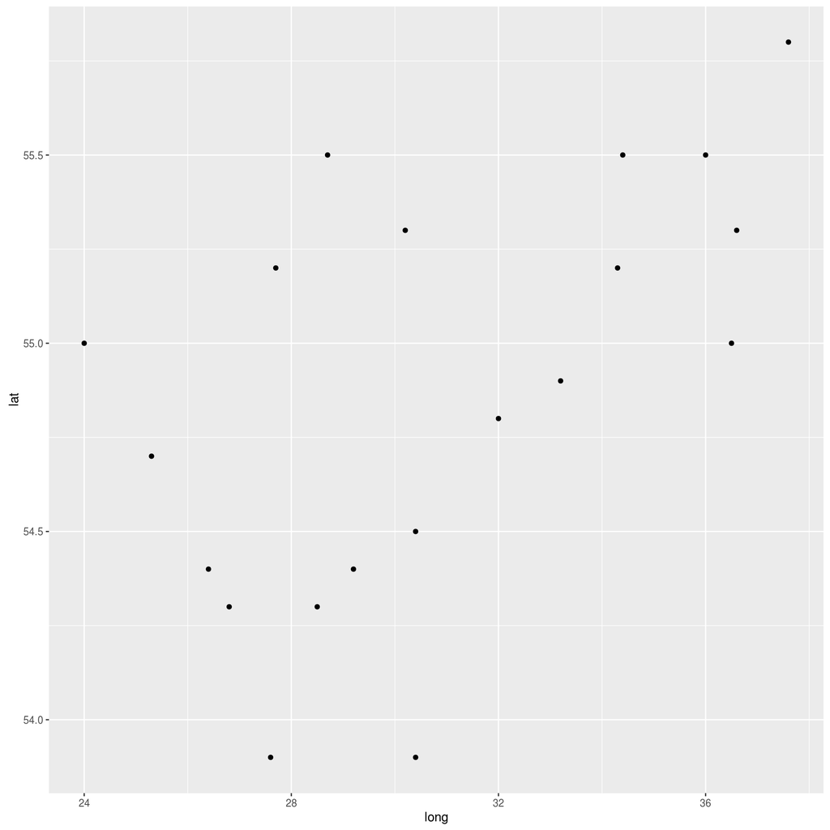

```r
ggplot(Minard.cities, aes(x=long, y=lat)) +
  geom_point()
```

# Nasz pierwszy wykres

Alternatywne zapisy tego samego:

```r
g <- ggplot(Minard.cities, aes(x=long, y=lat))
g + geom_point()

ggplot() + geom_point(data=Minard.cities, aes(x=long, y=lat))
```

Dodajemy kolejną warstwę do wykresu: tekst.

```r
ggplot(Minard.cities, aes(x=long, y=lat)) +
  geom_point() +
  geom_text(aes(label = city))
```

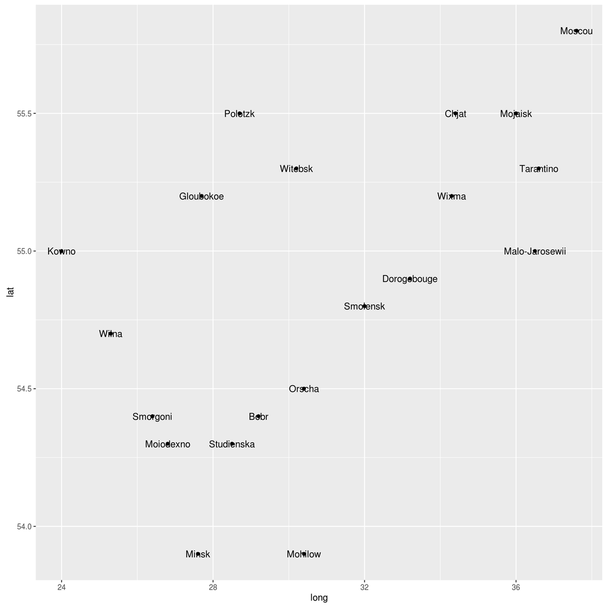

```r
ggplot(Minard.cities, aes(x=long, y=lat, label=city)) +
 geom_point() +
 geom_text()
```

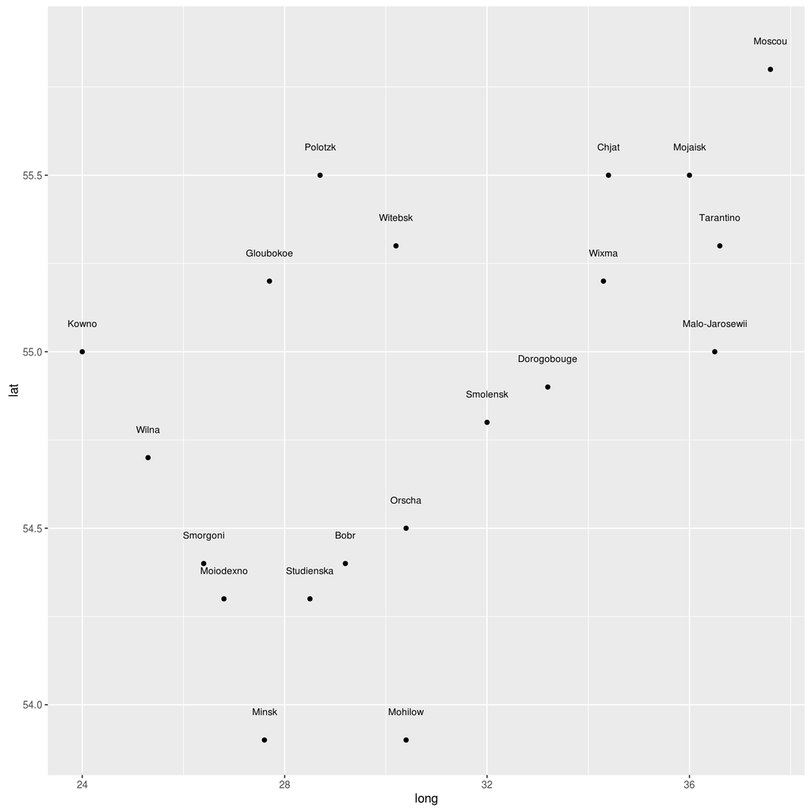

```r
ggplot(Minard.cities, aes(x=long, y=lat)) +
  geom_point() +
  geom_text(aes(label = city), size=3, nudge_y=0.08)
```

# Dwa zbiory danych na jednym wykresie

Dodamy nową warstwę ale z nowymi danymi. Aby nie kopowiać wielokrotnie tego samego początku, który rysuje nam miasta, możemy łatwo przypisać dotychczasowy wykres do zmiennej (nazwijmy ją `wykres`) i do tej zmiennej dodawać nowe warstwy!

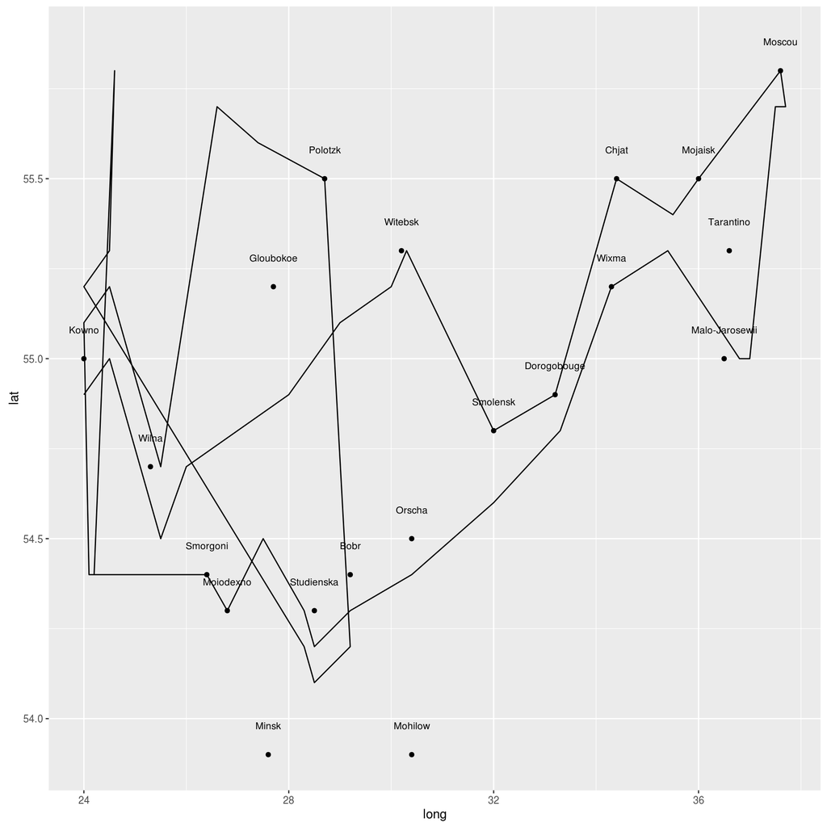

```r
wykres <- ggplot(Minard.cities, aes(x=long, y=lat)) +
  geom_point() +
  geom_text(aes(label = city), size=3, nudge_y=0.08)

wykres +
  geom_path(data=Minard.troops, aes(long,lat))
```

# Dwa zbiory danych na jednym wykresie

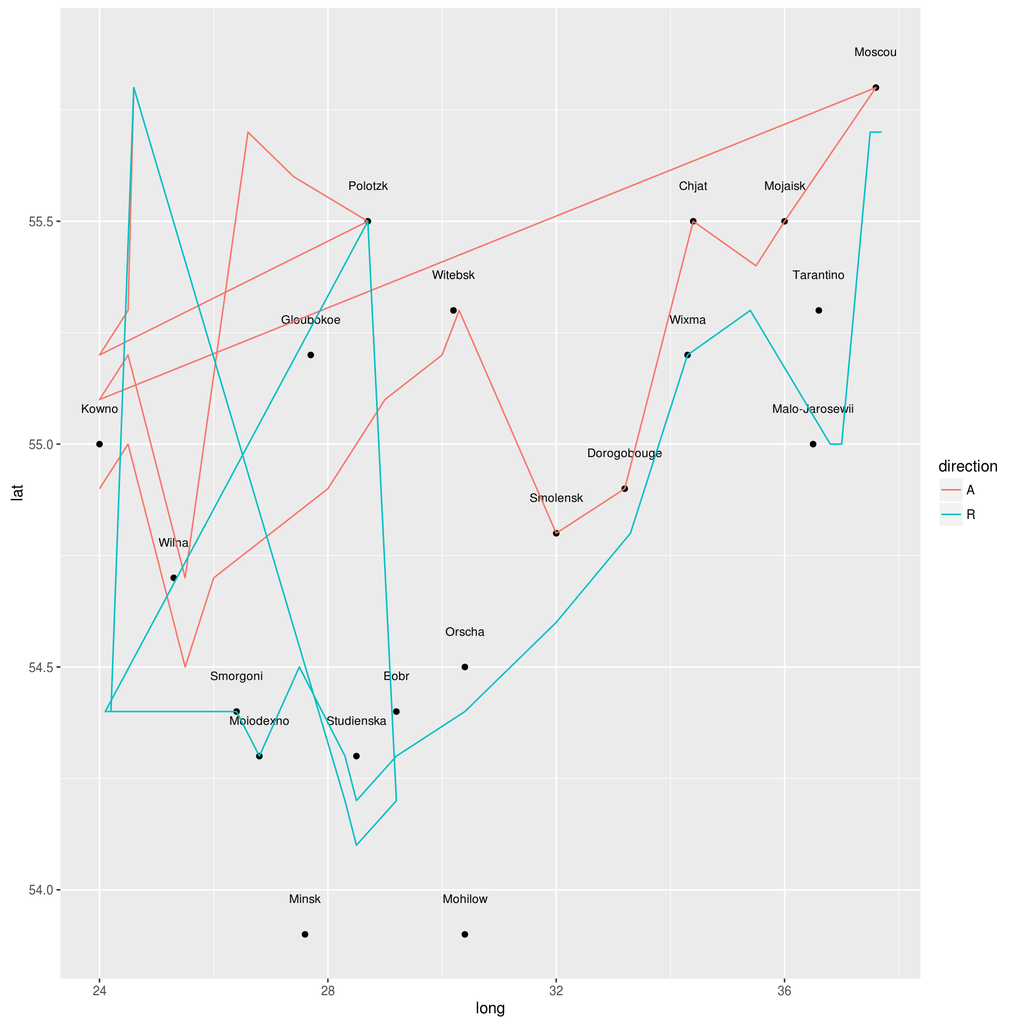

```r
wykres +
  geom_path(data=Minard.troops, aes(long,lat, color=direction) )
```

# Dwa zbiory danych na jednym wykresie

Plątatnina kresek z lewej strony wykresu w niczym nie przypomina oryginalnego dzieła Minarda. Widzimy, że `geom_path` łączy ze sobą wszystkie kolejne punkty, nie uwzględniając group żołnierzy, które odłączyły się w trakcie marszu. Pogrupujmy więc punkty (long, lat) wg. odpowiednich grup piechurów. Dołożymy również do wykresu tytuł: `ggtitle()` jest tylko jednym ze sposobów. Innym byłaby funkcja `labs()`.

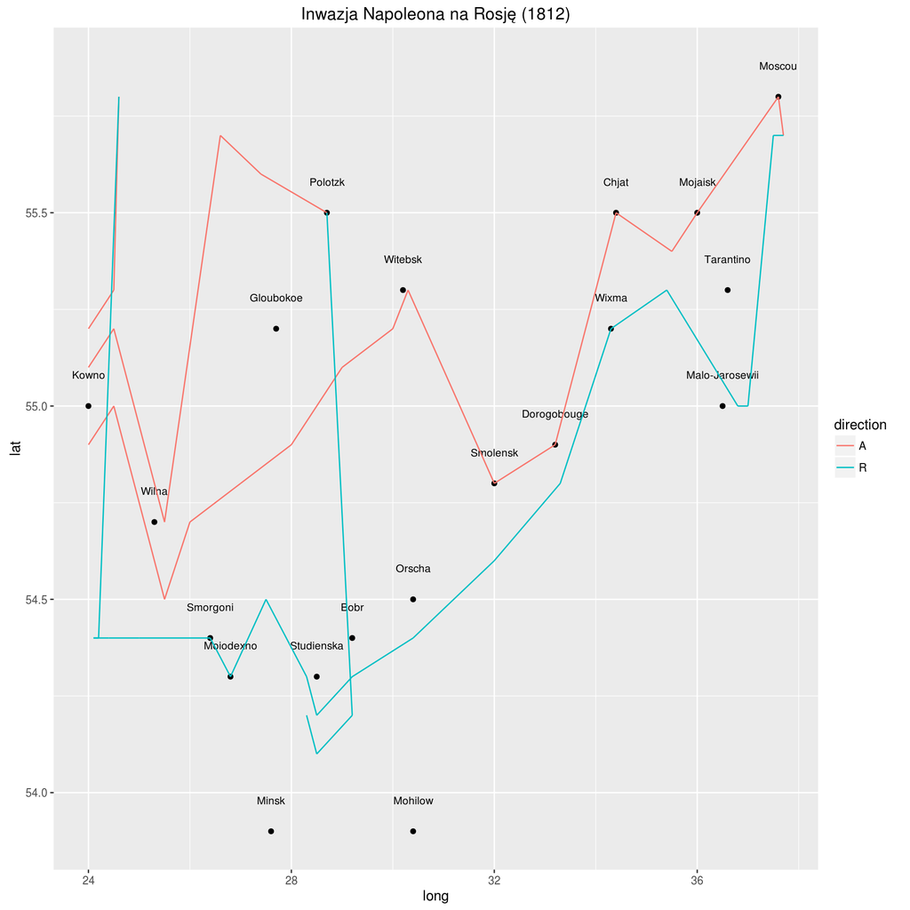

```r
wykres +
  geom_path(data=Minard.troops, aes(long,lat, color=direction, group=group) ) +
  ggtitle('Inwazja Napoleona na Rosję (1812)')
```

# Dwa zbiory danych na jednym wykresie

Jak wyrazić liczbę żołnieży poprzez grubość linii?

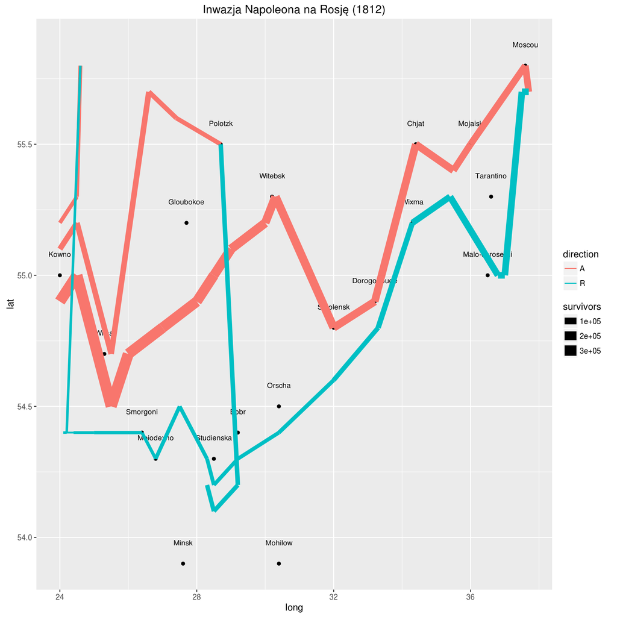

```r
wykres +
  geom_path(data=Minard.troops, aes(long,lat, color=direction, group=group, size=survivors)) +
  ggtitle('Inwazja Napoleona na Rosję (1812)')
```

# Estetyka

Jesteśmy coraz bliżej, popracujemy jeszcze nad kwestiami estetycznymi: kolorystyką oraz wyglądem legendy. Zauważmy, że mamy dwa typy legend na dwóch wymiarach wykresu: `size` oraz `colour`. Zmienna `survivors` leżąca na wymiarze `size` jest typu ciągłego. Do poprawki legendy wykorzystamy parametr `scale_*_**` w miejsce `*` wstawiając odpowiedni wymiar.

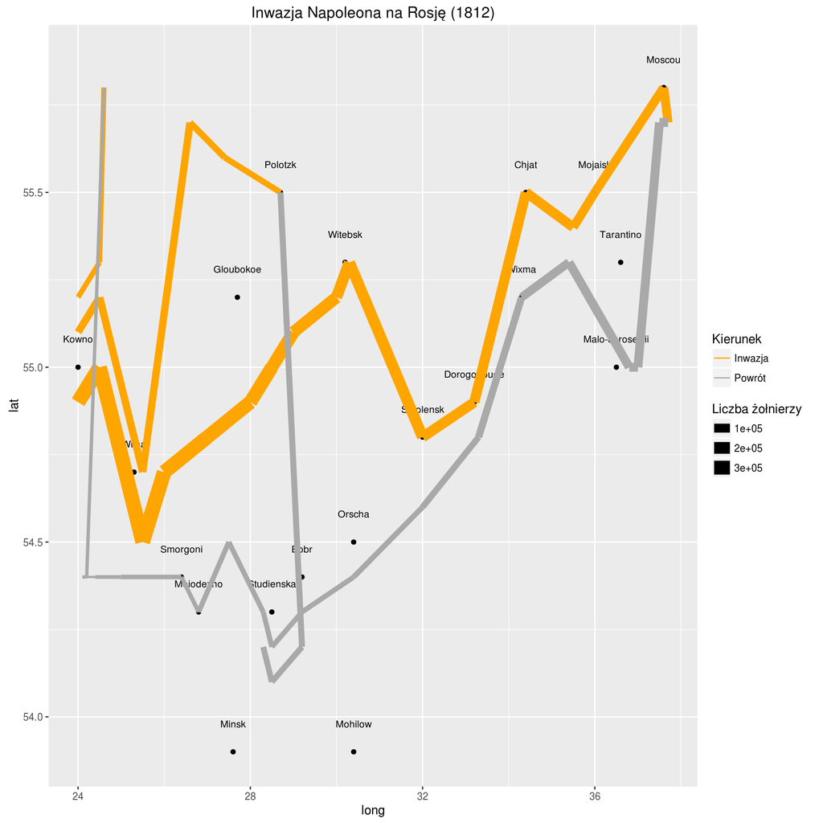

```r
wykres +
  geom_path(data=Minard.troops, aes(long,lat, colour=direction, group=group, size=survivors)) +
  ggtitle('Inwazja Napoleona na Rosję (1812)') +
  scale_colour_manual(values=c("orange","darkgray"), labels=c('Inwazja', 'Powrót'), name='Kierunek') +
  scale_size_continuous(name = 'Liczba żołnierzy')
```

Powyższy rysunek jest dobrym przykładem tego, że kolejne warstwy nakładają się na siebie: punkty i nazwy miast, które umieściłyśmy na początku zostały prawie zupełnie przykryte naszą ścieżką. Poprawimy to na kolejnym przykładzie, zmieniając kolejność nakładanych warstw. Zobaczymy przy okazji w jaki sposób wygląda całościowy kod tworzący nasz obrazek.

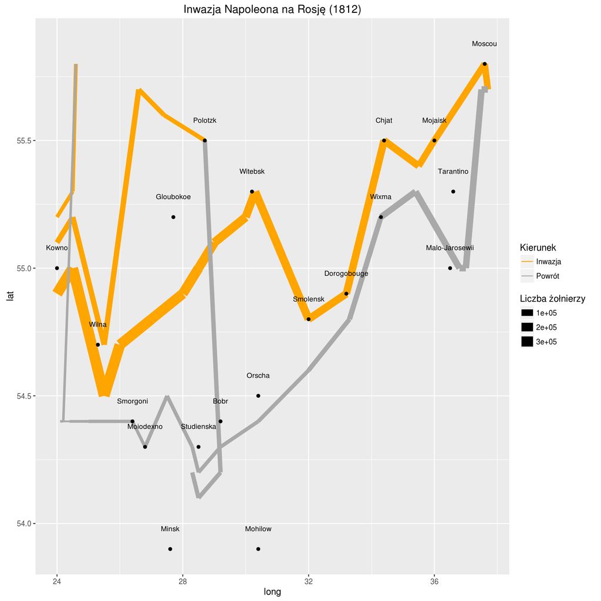

```r
ggplot(Minard.cities, aes(x=long, y=lat)) +
  geom_path(data=Minard.troops, aes(long,lat, color=direction, group=group, size=survivors)) +
  ggtitle('Inwazja Napoleona na Rosję (1812)') +
  scale_colour_manual(values=c("orange","darkgray"), labels=c('Inwazja', 'Powrót'), name='Kierunek') +
  scale_size_continuous(name = 'Liczba żołnierzy') +
  geom_point() +
  geom_text(aes(label = city), size=3, nudge_y=0.08)
```

# Wykres temperatury (Ćwiczenie)

Wykorzystajmy zbiór `Minard.temp` do narysowania wykresu temperatury na danej długości geograficznej. Przykładowy wykres może wyglądać następująco:

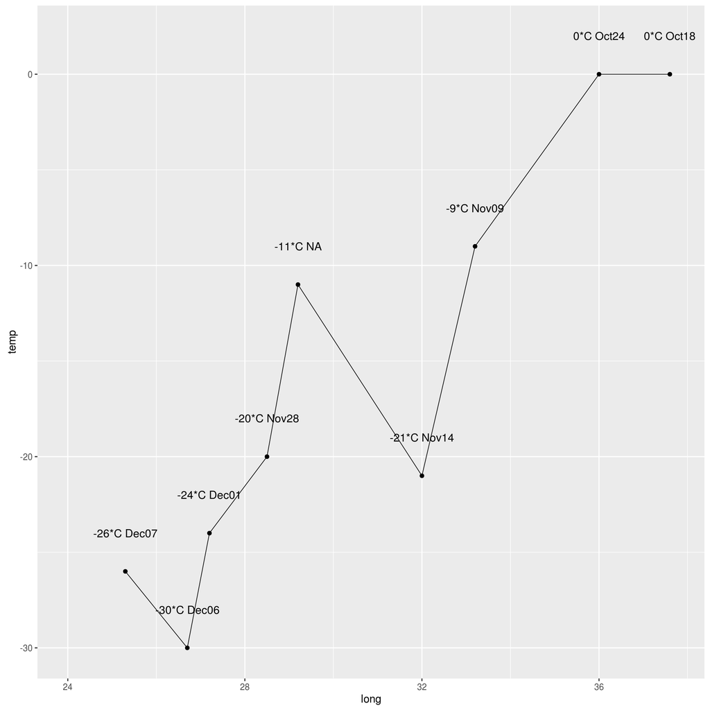

# Inne pożyteczne wykresy:

### Zależność zmiennej ciągłej od kategorialnej.

Zmienianie się liczby żołnierzy podczas wyprawy, w poszczególnych grupach. `ggplot()` oraz funkcja `aes()` wymagają, aby zmienna przechowująca nazwy kategorii, była typu `factor()`. Na wszelki wypadek, warto taki typ wymusić.

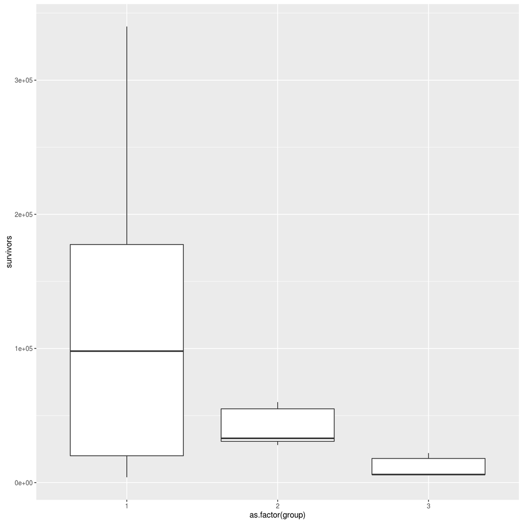

```r
ggplot(Minard.troops, aes(x=as.factor(group), y=survivors)) +
  geom_boxplot()
```

# Inne pożyteczne wykresy

### Grupowanie boxplotów za pomocą wypełnienia wykresu.

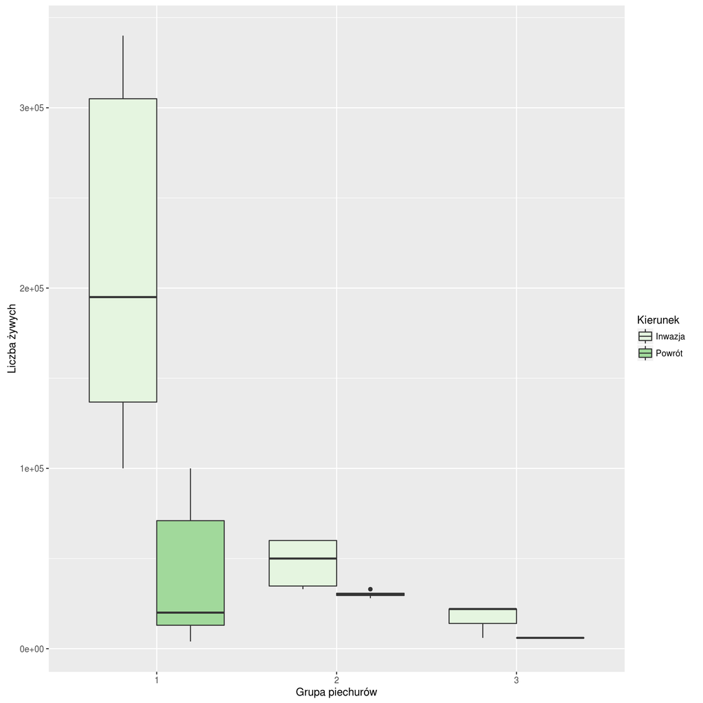

```r
ggplot(Minard.troops) +
  geom_boxplot(aes(x=as.factor(group), y=survivors, fill=direction)) +
  labs( x='Grupa piechurów', y = 'Liczba żywych', fill='Kierunek') +
  scale_fill_brewer(labels=c('Inwazja','Powrót'), palette=5)
```

# Inne pożyteczne wykresy

### Grupowanie wykresów z wykorzystaniem paneli.

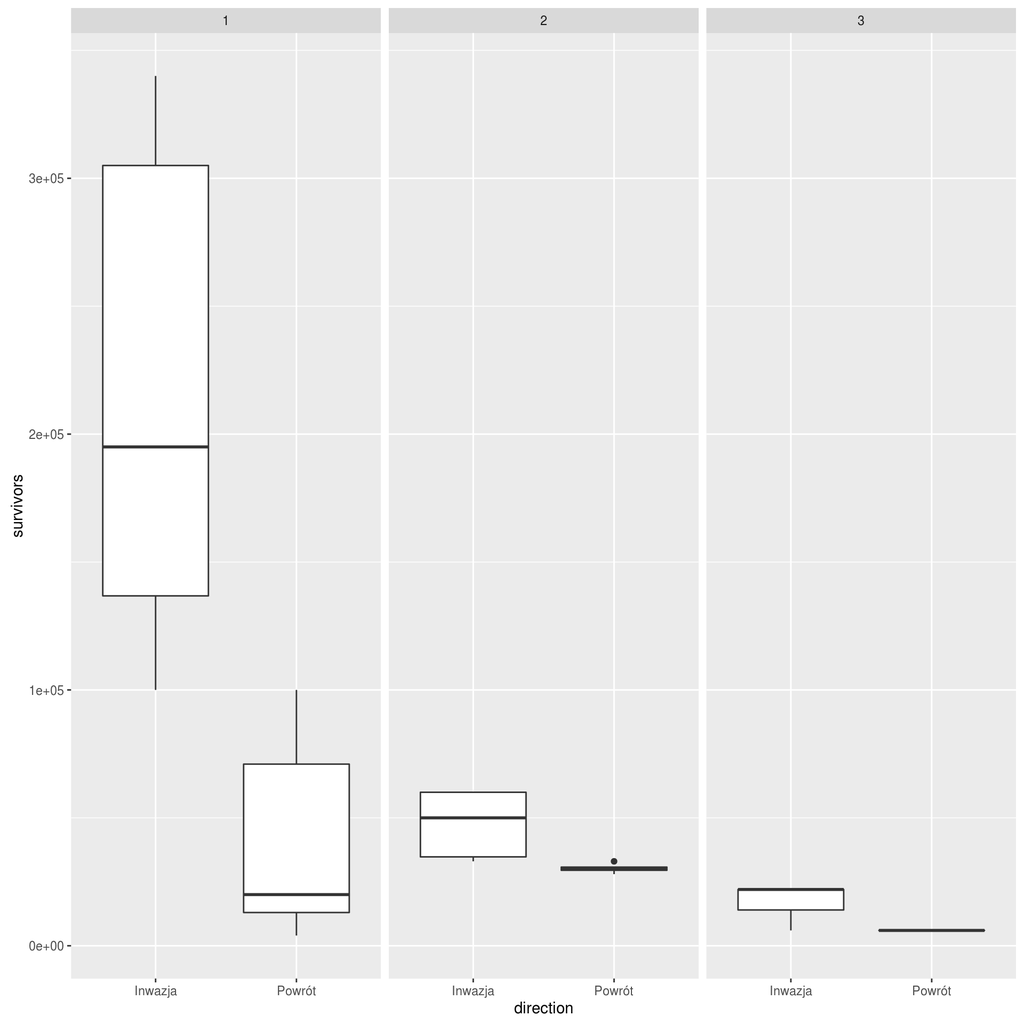

```r
ggplot(Minard.troops) +
  geom_boxplot(aes(x=direction, y=survivors)) +
  scale_x_discrete(labels=c('Inwazja','Powrót')) +
  facet_grid( ~group )
```

# Zadania samodzielne

Poniżej podaję proste zadania do samodzielnego wykonania oraz przykładowe rozwiązanie.

```r
library(PogromcyDanych)
```

### 2. WYKRES PUDEŁKOWY 1

#### Wybierz ulubiony serial. Jakie miał oceny w poszczególnych sezonach?

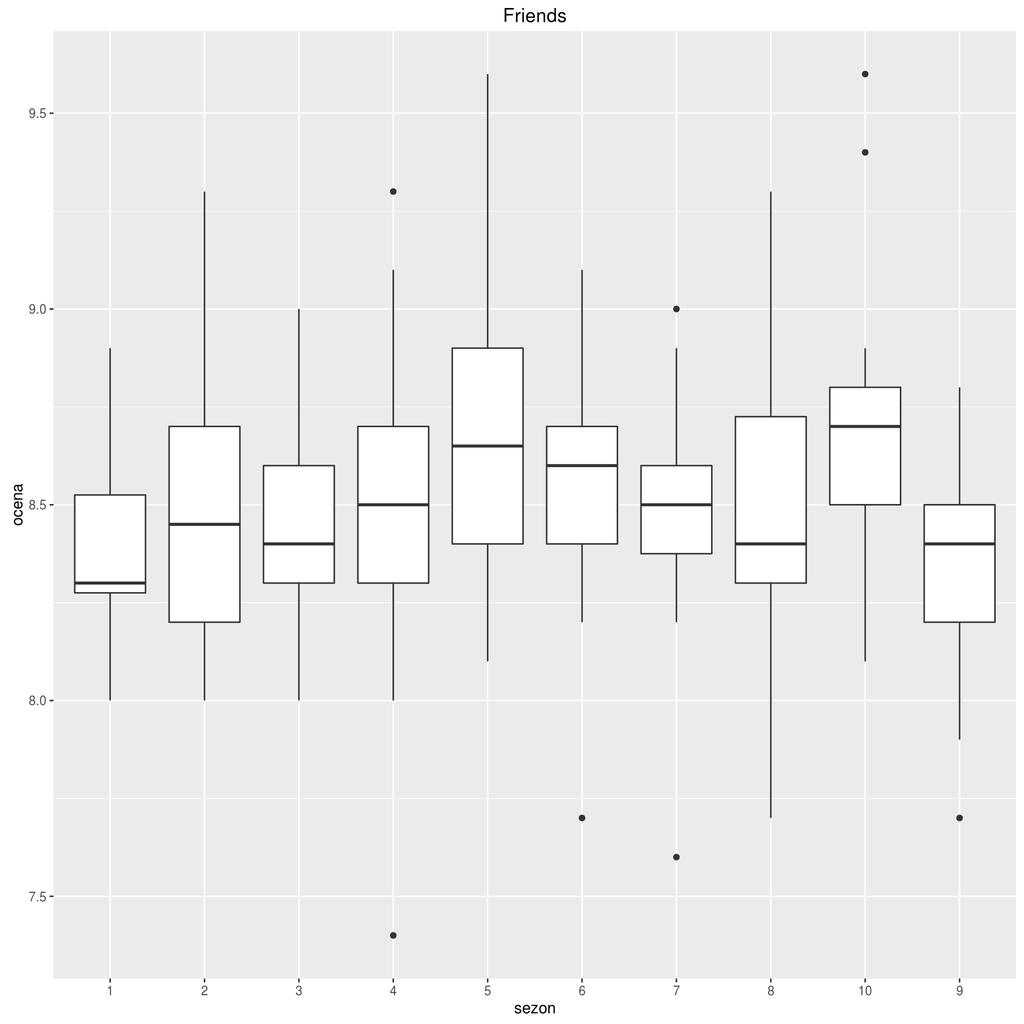

### 3. WYKRES PUDEŁKOWY 2

#### Wybierz kilka seriali. Który z nich miał lepsze noty? Jak zmieniała się opinia widowni w poszczególnych sezonach?

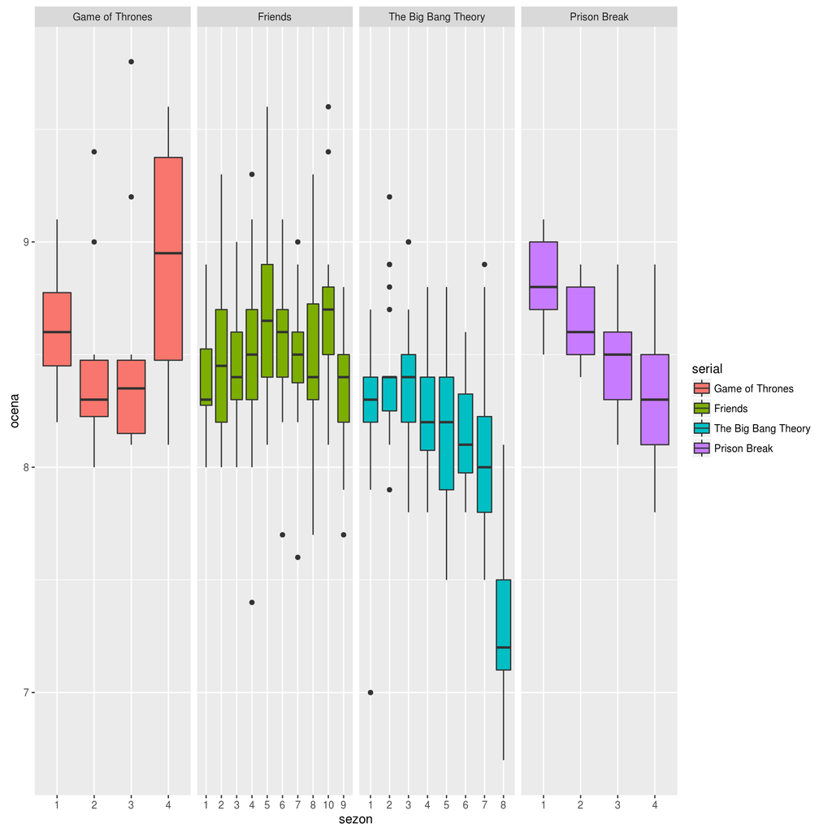

### 4. WYKRES SŁUPKOWY

#### Ile było dodanych głosów w najchętniej i najmniej chętnie oglądanym sezonie wybranego serialu? Jaka to była ocena?

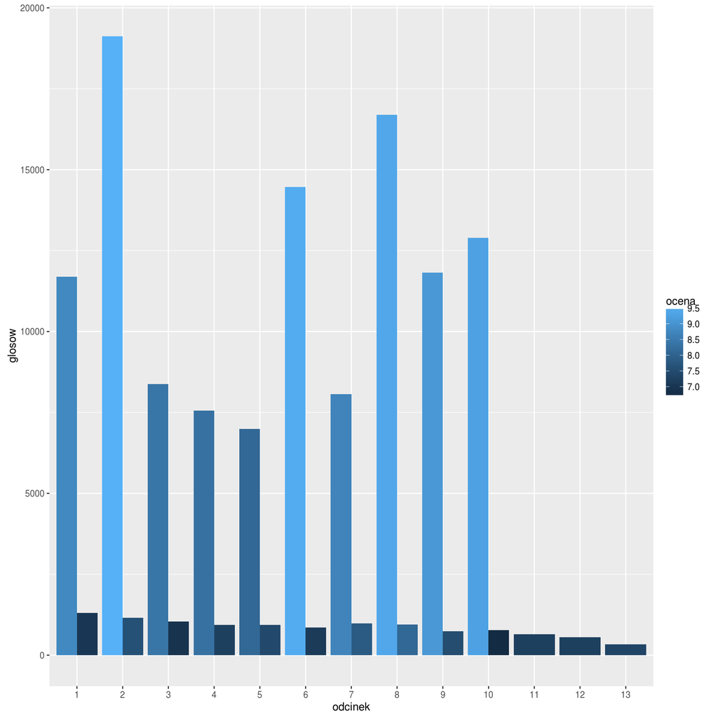